[GitHub](https://github.com/agate-model/Agate.jl)[](https://github.com/agate-model/Agate.jl/blob/main/examples/forward_mode_ad_nipizd_sensitivity.jl)

# Forward-mode AD sensitivity

In this example we use ForwardDiff.jl to compute the sensitivity of phytoplankton 1 (P*1) in an N2P2ZD model to P*1's maximum growth rate parameter.

## Loading dependencies

The example uses Agate.jl for the ecosystem model, OrdinaryDiffEq.jl for a small standalone ODE solve, ForwardDiff.jl for the derivative, and CairoMakie.jl for plotting.

```julia
using Agate
using ForwardDiff
using OrdinaryDiffEq: Tsit5, solve
using CairoMakie
using Printf

using Oceananigans.Biogeochemistry: required_biogeochemical_tracers
using Oceananigans.Units: day

const NiPiZD = Agate.Models.NiPiZD
const TRACERS = (:N, :D, :P_1, :P_2, :Z_1, :Z_2)
```

## Static model and active parameter

We construct the model once and let `Agate.Runtime.ode_problem` read P_1's maximum growth rate from the ODE parameter vector. During ForwardDiff.jl calls only this active entry becomes a dual number; the stored model parameters remain ordinary floating-point values.

```julia
const BGC = NiPiZD.construct()
const ACTIVE = Agate.Runtime.active_parameters(BGC; maximum_growth_rate=(:P_1,))
```

```
Agate.Runtime.ActiveParameterSet{@NamedTuple{maximum_growth_rate::Tuple{@NamedTuple{indices::Tuple{Int64}, active_index::Int64}}}, Vector{Float64}, @NamedTuple{maximum_growth_rate::Tuple{Symbol}}}((maximum_growth_rate = ((indices = (1,), active_index = 1),),), ("maximum_growth_rate.P_1",), [1.867252122574883e-5], (maximum_growth_rate = (:nonnegative,),))
```

Here `theta[1]` is the maximum growth rate of `P_1`. The `P_2` growth rate and omitted zooplankton entries are held fixed at the model defaults.

## Standalone ODE problem

We define a small standalone ODE through Agate.jl's SciML problem helper.

```julia
function initial_conditions(::Type{T}) where {T}
    return T[7.0, 1.0, 0.01, 0.01, 0.05, 0.05]
end

constant_PAR(::Type{T}) where {T} = T(100.0)

function solve_nipizd(theta; saveat=range(0.0, 365day; length=366))
    T = eltype(theta)

    required_biogeochemical_tracers(BGC) == TRACERS ||
        error("Unexpected NiPiZD tracer order: $(required_biogeochemical_tracers(BGC))")

    problem = Agate.Runtime.ode_problem(
        BGC,
        initial_conditions(T),
        (first(saveat), last(saveat));
        p=theta,
        active_parameters=ACTIVE,
        auxiliary=(; PAR=t -> constant_PAR(T)),
    )

    return solve(problem, Tsit5(); saveat=saveat, abstol=1e-10, reltol=1e-10)
end
```

We expose the `P_1` trajectory (e.g. biomass values over time) as a vector-valued function of one parameter. This is the function that ForwardDiff.jl differentiates.

```julia
function p_1_trajectory(theta; saveat=range(0.0, 365day; length=366))
    sol = solve_nipizd(theta; saveat=saveat)
    values = reduce(hcat, sol.u)
    return vec(values[3, :])
end

function p_1_solution(mu; saveat=range(0.0, 365day; length=366))
    sol = solve_nipizd([mu]; saveat=saveat)
    values = reduce(hcat, sol.u)
    return vec(values[3, :])
end
```

## ForwardDiff.jl and finite differences

We compute the time-dependent sensitivity of `P_1` to its own maximum growth rate. A central finite difference provides a simple independent check.

```julia
function finite_difference_p_1_trajectory(mu0, delta; saveat)
    plus = p_1_trajectory([mu0 + delta]; saveat=saveat)
    minus = p_1_trajectory([mu0 - delta]; saveat=saveat)
    return (plus .- minus) ./ (2delta)
end

saveat = collect(range(0.0, 365day; length=366))
mu0 = 0.7 / day
delta = mu0 * 1e-6

baseline = p_1_solution(mu0; saveat=saveat)
J = ForwardDiff.jacobian(theta -> p_1_trajectory(theta; saveat=saveat), [mu0])
forwarddiff_sensitivity = J[:, 1]
finite_difference_sensitivity = finite_difference_p_1_trajectory(mu0, delta; saveat=saveat)

@printf("Final dP_1/dmu, ForwardDiff:       %.8e\n", forwarddiff_sensitivity[end])
@printf("Final dP_1/dmu, finite difference: %.8e\n", finite_difference_sensitivity[end])
@printf(
    "Maximum absolute sensitivity difference: %.8e\n",
    maximum(abs.(forwarddiff_sensitivity .- finite_difference_sensitivity)),
)
```

```
Final dP_1/dmu, ForwardDiff:       1.92898613e+04
Final dP_1/dmu, finite difference: 1.92898613e+04
Maximum absolute sensitivity difference: 1.50696311e+00
```

## Plotting

The top panel shows P_1 biomass over time. The bottom panel compares the ForwardDiff.jl sensitivity with the central finite difference estimate.

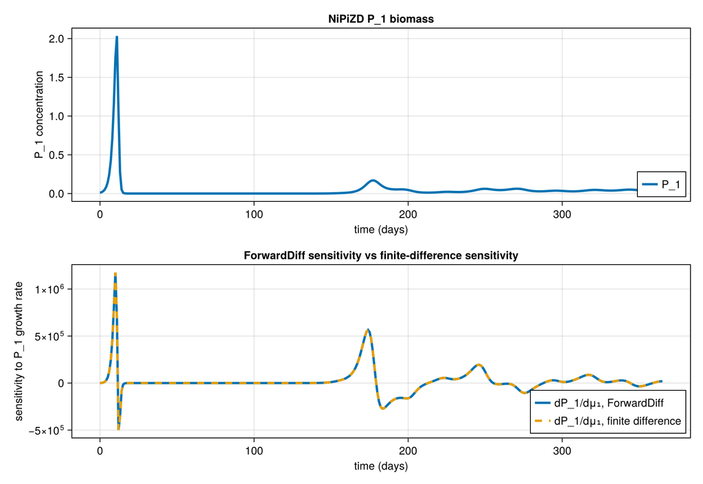

```julia
time_days = saveat ./ day
fig = Figure(; size=(900, 620), fontsize=14)

ax1 = Axis(
    fig[1, 1]; xlabel="time (days)", ylabel="P_1 concentration", title="NiPiZD P_1 biomass"
)
lines!(ax1, time_days, baseline; label="P_1", linewidth=3)
axislegend(ax1; position=:rb)

ax2 = Axis(
    fig[2, 1];
    xlabel="time (days)",
    ylabel="sensitivity to P_1 growth rate",
    title="ForwardDiff sensitivity vs finite-difference sensitivity",
)
lines!(ax2, time_days, forwarddiff_sensitivity; label="dP_1/dμ₁, ForwardDiff", linewidth=3)
lines!(
    ax2,
    time_days,
    finite_difference_sensitivity;
    linestyle=:dash,
    label="dP_1/dμ₁, finite difference",
    linewidth=3,
)
axislegend(ax2; position=:rb)

output_path = joinpath(@__DIR__, "forward_mode_ad_nipizd_sensitivity.png")
save(output_path, fig)

fig
```

*This page was generated using Literate.jl.*